# projek_mini_kelompok01

**MINI PROJECT: PROGRAM FILTERING DAN SORTING DATA**

Program ini berbasis Python dan iprogram menggunakan Jupyter Notebook. Projek ini dibuat dan disusun oleh Kelompok 01 kelas RB dengan topik program filtering dan sorting data.

```
Ernis Selfiana Saputri - 124400008
Safa Kalia - 124400020
Sulthan Fawwaz Hariri - 124400022
```

# Import Library

Pertama-tama kita perlu melakukan *Import Library,* command ini berguna untuk mengimpor library dasar (seperti mendownload aplikasi sementara) yaitu library *Pandas* yang digunakan untuk membaca file CSV (read_csv) dan menangani struktur data tabel (DataFrame) dengan lebih mudah.dan *matplotlib* yang akan digunakan untuk melakukan *visualisasi.* (Visualisasi dalam Python adalah proses membuat representasi grafis dari data untuk membantu dalam eksplorasi, analisis, dan penyampaian informasi.)

```python
import csv
import matplotlib.pyplot as plt
import pandas as pd
# Agar grafik muncul langsung di notebook
%matplotlib inline
```

# OOP (Object-Oriented Programming): Class DataManager

Struktur utama program dibangun menggunakan konsep Pemrograman Berorientasi Objek (OOP) melalui pendefinisian class bernama DataManager. Di dalam class ini, terdapat metode konstruktor (**init**) yang bertugas memuat file CSV secara otomatis saat objek dibuat. Bagian ini dirancang sangat kuat (robust) dengan menerapkan blok penanganan error (try-except). Mekanisme ini berfungsi untuk mengantisipasi masalah teknis, seperti file yang tidak ditemukan atau format data yang kosong, sehingga program akan memberikan pesan peringatan yang jelas alih-alih berhenti mendadak (crash).

```python
import pandas as pd
class DataManager:
    def __init__(self, nama_file):
        self.nama_file = nama_file
        try:
            # Memuat data langsung ke dalam variabel instance
            self.data_mentah = pd.read_csv(nama_file)
            # Inisialisasi data_olah di sini, di dalam method tempat self didefinisikan
            self.data_olah = []
        except FileNotFoundError:
            print(f"ERROR: File '{nama_file}' tidak ditemukan. Mohon pastikan file CSV berada di direktori yang benar.")
            self.data_mentah = pd.DataFrame() # Inisialisasi sebagai DataFrame kosong untuk mencegah error selanjutnya
            self.data_olah = []
        except pd.errors.EmptyDataError:
            print(f"ERROR: File '{nama_file}' kosong. Tidak ada data untuk diproses.")
            self.data_mentah = pd.DataFrame()
            self.data_olah = []
        except Exception as e:
            print(f"Terjadi kesalahan saat membaca '{nama_file}': {e}")
            self.data_mentah = pd.DataFrame()
            self.data_olah = []

   # --- Untuk memproses data mentah dan menangani header ---
    def process_raw_data(self):
        if self.data_mentah.empty:
            print("PERINGATAN: Tidak ada data mentah untuk diproses. DataManager mungkin tidak memuat file dengan benar.")
            return
        try:
            # Asumsi: Header kolom berada di baris ke-3 (index 2)
            # dan data dimulai dari baris ke-4 (index 3)
            headers = self.data_mentah.iloc[2].tolist()
            data_rows = self.data_mentah.iloc[3:].values.tolist()

            processed_data = []
            for row in data_rows:
                processed_data.append(dict(zip(headers, row)))
            # Perbarui data_mentah menjadi list of dictionaries yang sudah diproses
            self.data_mentah = processed_data
        except IndexError:
            print("ERROR: Tidak dapat menemukan baris header (index 2) atau baris data (mulai index 3). Periksa struktur CSV.")
            self.data_mentah = []
        except Exception as e:
            print(f"Terjadi kesalahan saat memproses data mentah: {e}")
            self.data_mentah = []

    # --- 2. Fungsi & Lambda (Menghitung Nilai Akhir) ---
    def hitung_nilai_akhir(self):
        # Periksa apakah DataFrame kosong SEBELUM memprosesnya menjadi list of dictionaries
        if self.data_mentah.empty:
            print("INFO: Tidak ada data mentah (DataFrame kosong) untuk menghitung nilai akhir. Perhitungan dilewati.")
            return

        self.process_raw_data() # Proses DataFrame mentah menjadi list of dictionaries terlebih dahulu

        # Setelah process_raw_data, self.data_mentah sekarang berupa list of dictionaries.
        # Pemeriksaan ini sekarang valid untuk list kosong.
        if not self.data_mentah:
            print("INFO: Tidak ada data yang tersedia setelah pemrosesan data mentah. Perhitungan dilewati.")
            return

        self.data_olah = [] # Reset list
        for mhs in self.data_mentah:
            try:
                # Pastikan nilai berupa float untuk perhitungan
                tugas = float(mhs.get('nilai_tugas', 0))
                ujian = float(mhs.get('nilai_ujian', 0))
                # Lambda: Rumus Nilai Akhir = (30% Tugas) + (70% Ujian)
                rumus_akhir = lambda t, u: (0.3 * t) + (0.7 * u)
                akhir = rumus_akhir(tugas, ujian)
                # Tambahkan nilai_akhir ke dictionary mahasiswa dan tambahkan ke data_olah
                mhs['nilai_akhir'] = round(akhir, 2)
                self.data_olah.append(mhs)
            except ValueError:
                print(f"PERINGATAN: Tidak dapat mengubah 'nilai_tugas' atau 'nilai_ujian' menjadi angka untuk mahasiswa {mhs.get('nama', 'Tidak Diketahui')}. Mengatur nilai_akhir menjadi 0.")
                mhs['nilai_akhir'] = 0
                self.data_olah.append(mhs)
            except KeyError as ke:
                print(f"PERINGATAN: Kunci '{ke}' yang diharapkan hilang untuk mahasiswa {mhs.get('nama', 'Tidak Diketahui')}. Mengatur nilai_akhir menjadi 0 dan menambahkannya.")
                mhs['nilai_akhir'] = 0 # Default jika kunci hilang
                self.data_olah.append(mhs) # Pastikan mahasiswa tetap ditambahkan
            except Exception as e:
                print(f"Terjadi kesalahan untuk mahasiswa {mhs.get('nama', 'Tidak Diketahui')} selama perhitungan nilai: {e}")
                mhs['nilai_akhir'] = 0 # Default jika ada kesalahan lain
                self.data_olah.append(mhs)

   # --- 3. Filtering (Branching & Looping) ---
    def filter_lulus(self, kkm=75):
        print(f"\n--- FILTER: MAHASISWA LULUS (Nilai >= {kkm}) ---")
        if not self.data_olah:
            print("INFO: Tidak ada data olahan yang tersedia untuk pemfilteran.")
            return []
        lulus = [mhs for mhs in self.data_olah if mhs.get('nilai_akhir', 0) >= kkm]

        if not lulus:
            print("Tidak ada yang lulus.")
        else:
            for mhs in lulus:
                # Menggunakan 'Tidak Diketahui' jika nama tidak ada
                print(f"{mhs.get('nama', 'Tidak Diketahui')} \t: {mhs.get('nilai_akhir', 'N/A')} (Lulus)")
        return lulus

    # --- 4. Sorting (Menggunakan Lambda Key) ---
    def sort_ranking(self, ascending=False):
        print("\n--- SORTING: PERINGKAT NILAI ---")
        if not self.data_olah:
            print("INFO: Tidak ada data olahan yang tersedia untuk pengurutan.")
            return []
        try:
            # Menggunakan Lambda sebagai key untuk sorting berdasarkan 'nilai_akhir'
            data_sorted = sorted(self.data_olah, key=lambda x: x.get('nilai_akhir', 0), reverse=not ascending)

            for i, mhs in enumerate(data_sorted):
                print(f"Peringkat {i+1}: {mhs.get('nama', 'Tidak Diketahui')} ({mhs.get('jurusan', 'Tidak Diketahui')}) - Nilai: {mhs.get('nilai_akhir', 'N/A')}")

            return data_sorted
        except Exception as e:
            print(f"Terjadi kesalahan saat pengurutan: {e}")
            return []

    # --- 5. Visualisasi Data ---
    def visualisasi_top_5(self, data_sorted):
        if not data_sorted:
            print("PERINGATAN: Tidak ada data terurut yang tersedia untuk visualisasi.")
            return
        try:
            # Ambil 5 data teratas
            top_5 = data_sorted[:5]

            nama = [mhs.get('nama', 'Tidak Diketahui') for mhs in top_5]
            nilai = [mhs.get('nilai_akhir', 0) for mhs in top_5]

            plt.figure(figsize=(8, 5))
            # Bar chart dengan warna berbeda-beda agar menarik
            colors = ['#1f77b4', '#ff7f0e', '#2ca02c', '#d62728', '#9467bd']
            plt.bar(nama, nilai, color=colors)

            plt.title('Top 5 Mahasiswa Nilai Tertinggi')
            plt.xlabel('Nama Mahasiswa')
            plt.ylabel('Nilai Akhir')
            plt.ylim(80, 100) # Batas sumbu Y 0-100

            # Menambah label angka di atas batang
            for i, v in enumerate(nilai):
                plt.text(i, v + 1, str(v), ha='center')

            plt.show()
        except Exception as e:
            print(f"Terjadi kesalahan saat visualisasi: {e}")
```

# Main Execution

Blok terakhir kode merupakan pengendali utama seluruh alur program. Di sini, proses instansiasi dilakukan dengan menciptakan objek dari DataManager yang merujuk pada file 'Data Nilai.csv'. Selanjutnya, program memanggil fungsi-fungsi method yang telah didefinisikan sebelumnya secara berurutan—mulai dari perhitungan nilai, penyaringan data lulus, pengurutan peringkat, hingga akhirnya menampilkan grafik. Seluruh proses eksekusi ini juga dibungkus dalam mekanisme penanganan error untuk menjamin program berjalan mulus dari awal hingga akhir.

```
--- FILTER: MAHASISWA LULUS (Nilai >= 70) ---
Sulthan 	: 83.5 (Lulus)
Ernis 	: 93.5 (Lulus)
Febrio 	: 78.0 (Lulus)
Hyanggi 	: 91.5 (Lulus)
Aura 	: 85.9 (Lulus)
Cindy 	: 89.2 (Lulus)
Anisa 	: 71.5 (Lulus)
Angela 	: 88.5 (Lulus)

--- SORTING: PERINGKAT NILAI ---
Peringkat 1: Ernis (Teknik Telekomunikasi) - Nilai: 93.5
Peringkat 2: Hyanggi (Teknik Telekomunikasi) - Nilai: 91.5
Peringkat 3: Cindy (Teknik Telekomunikasi) - Nilai: 89.2
Peringkat 4: Angela (Teknik Telekomunikasi) - Nilai: 88.5
Peringkat 5: Aura (Teknik Telekomunikasi) - Nilai: 85.9
Peringkat 6: Sulthan (Teknik Telkomunikasi) - Nilai: 83.5
Peringkat 7: Febrio (Teknik Telekomunikasi) - Nilai: 78.0
Peringkat 8: Anisa (Teknik Telekomunikasi) - Nilai: 71.5
Peringkat 9: Zilva (Teknik Telekomunikasi) - Nilai: 66.5
Peringkat 10: Safa (Teknik Telekomunikasi) - Nilai: 56.5
Peringkat 11: Rojak (Teknik Telekomunikasi) - Nilai: 48.5
Peringkat 12: Vera (Teknik Telekomunikasi) - Nilai: 43.0
```

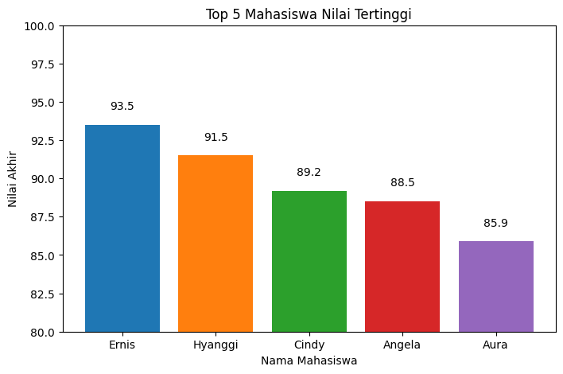

```python
try:
    # 1. Inisialisasi
    app = DataManager('Data Nilai.csv')

    # Metode 'load_data()' tidak lagi diperlukan karena pemuatan data dilakukan di dalam __init__
    # app.load_data()

    # 3. Hitung Nilai Akhir (Transformasi Data)
    app.hitung_nilai_akhir()

    # 4. Filter Data (Menampilkan yang lulus saja)
    data_lulus = app.filter_lulus(kkm=70) # Kita set KKM 70

    # 5. Sorting Data (Mendapatkan Ranking)
    # Kita simpan hasil sorting ke variabel untuk divisualisasikan
    data_ranking = app.sort_ranking(ascending=False)

    # 6. Visualisasi
    app.visualisasi_top_5(data_ranking)
except Exception as e:
    print(f"Terjadi kesalahan selama eksekusi program utama: {e}")
```